# td3 – MA1AY010 Probabilités

**NoteTD III : Processus de branchement**

- 18 Septembre 2025-25 Septembre 2025
- Master I ISIFAR
- **Probabilités**

Un processus de Galton-Watson (processus de branchement homogène) est un processus stochastique en temps discret utilisé pour modéliser l’évolution d’une population où chaque individu se reproduit indépendamment des autres, suivant une même loi de probabilité donnée (appelée *loi de reproduction*).

Il a été introduit au XIXᵉ siècle par Francis Galton et Henry Watson our étudier la probabilité d’extinction des noms de famille (nobles). On commence avec une *génération initiale* (génération $0$) formée d’un individu. Chaque individu de la génération $n$ engendre un nombre aléatoire de descendants distribué selon la loi de reproduction. Les descendants forment la génération suivante ($n+1$). Les nombres de descendants des individus de la géneration $n$ forment une famille indépendante. Le nombre d’individus dans la génération $n$ est noté $Z_n$.

La question centrale (et angoissante) est : la population s’éteint-elle presque sûrement ($Z_n \to 0$) ou bien survit-elle avec une probabilité non nulle ?

On note $Q$ la *loi de reproduction* (loi sur $(\mathbb{N}, 2^{\mathbb{N}})$. On note $\mu$ son espérance. On note $G_Q$ la fonction génératrice des probabilités de la loi $Q$.  
On convient de $\mathbb{N}^* = \mathbb{N}\setminus \{0\}$.

**Exercice 1 (Branchement (Modélisation))**

Proposer une formalisation, c’est à dire un univers $\Omega$, une tribu $\mathcal{F}$ de parties de $\Omega$, et une loi de probabilité $P$ sur $(\Omega, \mathcal{F})$ sur lesquels on peut définir la collection de variables aléatoires $Z_0, Z_1, \ldots, Z_n, \ldots$. Préciser la loi conditionnelle de $Z_{n+1}$ sachant $\{ Z_n =k\}, k \in \mathbb{N}$.

**NoteSolution**

Pour chaque génération, on se donne une suite infinie d’entiers, soit un élément de $\mathbb{N}^{\mathbb{N}^*}$. L’ensemble $\mathbb{N}^{\mathbb{N}^*}$ n’est pas dénombrable.

Pour représenter la suite des générations, on se donne un élément de $\left(\mathbb{N}^{\mathbb{N}^*}\right)^{\mathbb{N}}$. Cet ensemble est en bijection avec $\mathbb{N}^{\mathbb{N}^* \times \mathbb{N}}$. On convient de $\Omega = \mathbb{N}^{\mathbb{N}^* \times \mathbb{N}}$. Pour $\omega \in \Omega$, $X^n_j(\omega)$ est le nombre d’enfants de l’individus $j \in \mathbb{N}^*$ dans la génération $n \in \mathbb{N}$.

Comme $\Omega$ n’est pas dénombrable, on ne choisit pas l’ensemble de ses parties comme tribu.

Pour la génération $n \in \mathbb{N}$, pour $k \in \mathbb{N}^*$, $\mathcal{G}^n_k$ est la tribu (de parties de $\mathbb{N}^{\mathbb{N}^*}$) engendrée par $X^n_{1}, X^n_2, \ldots, X^n_k$, et $\mathcal{G}^n$ est la tribu engendrée par $\left(\mathcal{G}^n_k\right)_{k \in \mathbb{N}^*}$. La tribu $\mathcal{G}^n= \sigma\left(\left(\mathcal{G}^n_k\right)_{k \in \mathbb{N}^*} \right)$ est la tribu engendrée par les événements cylindriques décrivant la génération $n$.

Pour chaque $n$, $\mathcal{F}_n = \sigma \left( \cup_{m\leq n} \mathcal{G}^m \right)$, la tribu engendrée par les $(X^m_j)_{m \leq n, j \in \mathbb{N}^*}$.

Enfin $\mathcal{F} = \sigma\left( \cup_n \mathcal{F}_n \right)$.

Pour chaque $n$, on munit la $n^{\text{ieme}}$ génération de la loi produit infinie qui étend les lois produits finies définies sur $\mathcal{G}^n_k$:
$$P\left\{ \bigwedge_{j \leq k} X^n_j = x^n_j\right\} = \prod_{j \leq k } Q\left\{X^n_j = x^n_j \right\}$$
pour $(x^n_j)_{1\leq j\leq k} \in \mathbb{N}^k$

On munit $(\Omega, \mathcal{F})$ de la loi produit infinie qui étend les les lois produits définies sur les $n$ premières générations.

La taille des générations $(Z_n)_{n \in \mathbb{N}}$ est définie récurrence. On a $Z_0=1$ et
$$Z_{n+1} = \sum_{j=1}^{Z_n} X^n_j$$

Pour tout $n$, $Z_n$ est $\mathcal{F}_{n-1}$-mesurable (vérification par récurrence sur $n$)

Pour tout $n$, $\mathcal{F}_{n-1}$ est indépendante de $\mathcal{G}^n$

**Exercice 2 (Branchement, Espérance conditionnelle)**

Calculer l’espérance conditionnelle de $Z_{n+1}$ sachant $\sigma(Z_n)$

**NoteSolution**

$$\begin{align*}
\mathbb{E}\left[ Z_{n+1} \mid \mathcal{F}_{n-1} \right]
& = \mathbb{E}\left[ \sum_{j=1}^{Z_n} X^n_j \mid \mathcal{F}_{n-1} \right] \\
& = \mathbb{E}\left[ \sum_{j=1}^{\infty} \mathbb{I}_{j \leq Z_n} X^n_j \mid \mathcal{F}_{n-1} \right] \\
& = \sum_{j=1}^{\infty} \mathbb{I}_{j \leq Z_n} \mathbb{E}\left[ X^n_j \mid \mathcal{F}_{n-1} \right] \\
& = \sum_{j=1}^{\infty} \mathbb{I}_{j \leq Z_n} \mathbb{E}\left[ X^n_j \right] \\
& = \sum_{j=1}^{Z_n} \mu \\
& = \mu \times Z_n
\end{align*}$$
On peut même conclure:
$$\mathbb{E}\left[ Z_{n+1} \mid Z_n \right] = \mu \times Z_n$$

**Exercice 3 (Branchement. Espérance taille des générations)**

Calculer $\mathbb{E} Z_n$ en fonction de $\mu$ et $n$.

**NoteSolution**

$$\mathbb{E} Z_{n+1} = \mathbb{E}\left[\mathbb{E}\left[ Z_{n+1} \mid Z_n \right] \right]= \mu \times \mathbb{E} Z_n$$
D’où:
$$\mathbb{E} Z_n = \mu^n$$

**ImportantConvention**

Selon la valeur de $\mu$ (espérance de la loi de reproduction), on distingue trois cas :

- $\mu<1$, cas sous-critique
- $\mu=1$, cas critique
- $\mu>1$, cas sur-critique

Dans tous les cas, on note $p_E$ la probabilité d’extinction (probabilité de l’événement $\cup_{n \in \mathbb{N}} \{ Z_n =0\}$).

**Exercice 4 (Branchement. Cas sous-critique)**

Cacluler $p_E$, la probabilité d’extinction dans le cas sous-critique.

**NoteSolution**

$$E = \cup_{n} \{ Z_n =0 \} = \cup_n \cap_{m \geq n} \{ Z_m = 0\}$$

$$\Omega \setminus E = \cap_n \{ Z_n > 0\}$$
Pour chaque $k$
$$P \left\{ \cap_n \{ Z_n > 0\} \right\} \leq P \{ Z_k > 0\}$$

Comme la suite des événements $\{ Z_n > 0\}$ est décroissante,

$$P \left\{ \cap_n \{ Z_n > 0\} \right\} \leq \lim_n P \{ Z_n > 0\}$$
. Comme
$$P \{ Z_n > 0\} \leq \mathbb{E} Z_n$$
on conclut dans le cas sous-critique $\mu <1$, que
$$P \left\{ \cap_n \{ Z_n > 0\} \right\}=0$$
Soit
$$P\{ E\} =1$$
(extinction presque sûre).

**Exercice 5 (Branchement. Cas sûr-critique)**

Montrer que dans tous les cas, $p_E$ est solution de l’équation $G_Q(x)=x \, .$

**NoteSolution**

$$E = \cup_{k=1}^\infty \{Z_1=k\} \cap_{j=1}^k {E_j}$$

$$\begin{align*}
p_{E}
& = \mathbb{E} \left[ \mathbb{E}[ \mathbb{I}_E \mid Z_1]\right] \\
& = \mathbb{E} \left[ p_E^{Z_1}\right] \\
& = G_Q(p_E)
\end{align*}$$
car $Z_1 \sim Q$.

La probabilité d’extinction satisfait l’équation:
$$p_E = G_Q(p_E)$$

La Figure 1 illustre le problème posé par l’équation $p_E=G_Q(p_E)$ lorsque la loi de reproduction $Q$ est la loi de Poisson de paramètre $\mu=1.5$. Les deux intersections entre la courbe en trait plein et la droite pointillée représentent les deux solutions de l’équation $p_E = G_Q(p_E)$.

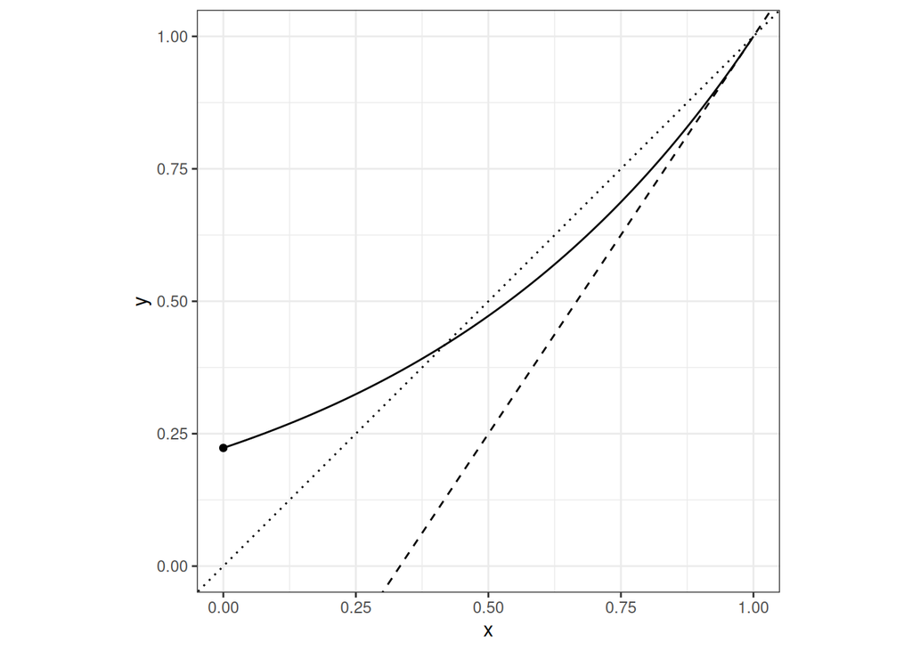

**Exercice 6 (Branchement. Cas sur-critique I)**

Étudier les solutions de l’équation $x=G_Q(x)$.

**NoteSolution**

Comme série entière de rayon de convergence $\geq 1$, dérivable en $1$, $G_Q$ possède les propriétés suivantes:

- $G_Q$ est croissante et convexe sur $[0,1]$, indéfiniment dérivable sur $]0,1[$
- La dérivée de $G_Q$ en $x=1$ est égale à l’espérance de la loi de reproduction $Q$, soit $\mu$.

La fonction $x \mapsto G_Q(x) -x$ est convexe, de dérivée $G'_Q-1$ sur $[0,1]$.

Si $\mu< 1$, la dérivée croît jusqu’à $0$ atteint en $x=1$. $G_Q(x)-x$ décroit donc de $Q(0)$ à $0$ entre $0$ et $1$. L’équation $x=G_Q(x)$ ne possède qu’une seule racine (triviale), $x=1$. On retrouve le fait que $p_E$ soit égal à $1$ dans le cas sous-critique.

Si $\mu > 1$, $G'_Q(0) -1= Q(\{1\})-1 < 0$ et $G'_Q(1)-1 = \mu-1>0$, $G_Q' -1$ s’annule en un $\theta \in ]0,1[$, est négative sur $[0,\theta]$, positive sur $[\theta,1]$. La fonction $G_Q(x)-x$ décroit de $0$ à $\theta$, croit de $\theta$ à $1$. Elle est positive en $0$ et nulle en $1$, elle s’annule donc une seule fois en tre $0$ et $\theta$. Dans le cas sur-critique, l’équation $x=G_Q(x)$ admet une racine non-triviale entre $0$ et $1$.

Pour déterminer $p_E$ dans le cas sur-critique, il faut déterminer la racine de l’équation $x=G_Q(x)$ qui est égale à $p_E$.

**Exercice 7 (Branchement. Cas sur-critique II)**

Déterminer $p_E$ dans le cas sur-critique.

**NoteSolution**

Pour déterminer $p_E$ dans le cas sur-critique, nous allons étudier la suite $\left(P\{ Z_n=0\}\right)_n$. C’est une suite croissante, majorée par $1$. Elle possède une limite dans $[0,1]$, et $p_E = \lim_{n} \uparrow P\{Z_n =0\}$.

On note $P\{Z_1=0\} = Q\{0\}$ ou encore $P\{Z_1=0\} = G_Q(0)$.

La relation entre $P\{Z_n=0\}$ et $G_Q$ est (relativement) simple et pas inattendue.

Si on note $G_{Z_n}$ la fonction génératrice de la loi de $Z_n$,  
on a d’abord $G_{Z_1}=G_Q$.

$$\begin{align*}
\mathbb{E} \left[s^{Z_{n+1}} \mid \sigma(Z_n) \right]
& = \mathbb{E} \left[s^{\sum_{i=1}^{Z_n} X^n_i} \mid \sigma(Z_n) \right] \\
& = \mathbb{E} \left[\prod_{i=1}^{Z_n} s^{X^n_i} \mid \sigma(Z_n) \right] \\
& = \prod_{i=1}^{Z_n} \mathbb{E} \left[ s^{X^n_i} \mid \sigma(Z_n) \right] \\
& = \prod_{i=1}^{Z_n} G_Q(s) \\
& = (G_Q(s))^{Z_n} \, .
\end{align*}$$

On en déduit:
$$G_{Z_{n+1}}(s) = \mathbb{E} \left[(G_Q(s))^{Z_n}\right] = G_{Z_n} (G_Q(s))$$

D’où (par récurrence sur $n$) :
$$G_{Z_n} = \underbrace{G_Q \circ \ldots \circ G_Q}_{n \text{ fois}}$$

Comme
$$P\{ Z_n = 0\} = G_{Z_n}(0)$$
on a
$$P\{ Z_n = 0\} = \underbrace{G_Q \circ \ldots \circ G_Q}_{n \text{ fois}}(0)$$
la suite $P\{ Z_n = 0\}$, vérifie la récurrence $u_{n+1} = G_Q(u_n)$ avec $u_1=Q\{0\}$.

Notons $\tau$ la solution non-triviale de $x=G_Q(x)$.

Si $u \in [0, \tau[$, alors
$$u < G_Q(u) < \tau$$

Cette observation permet de déduire que la suite $(u_n)_n$ définie par $u_{n+1} = G_Q(u_n)$ et $u_1=Q\{0\}$ et croissante et majorée par $\tau$. Elle admet une limite qui est un point fixe de $G_Q$, c’est donc $\tau$.

On peut donc conclure que dans le cas sur-critique, la probabilité d’extinction est la solution non-triviale de l’équation $x=G_Q(x)$.